# DV_RProject2

**Authors: Rolando Melendez, Hyunji Seo, Catherine Tu**

## Program file structure

00 Doc - contains .Rmd and .html

01 Data - contains the code to Extract, Transform, and Load our data

02 Data Wrangling - contains our workflows and the code for the visualizations

## Data summary and subset

```r
#Shows the subset and summary of the data frame
source("../01 Data/R_Load.R", echo = TRUE)
```

```
##
## > require("jsonlite")
```

```
##
## > require("RCurl")
```

```
##
## > df <- data.frame(fromJSON(getURL(URLencode("129.152.144.84:5001/rest/native/?query=\"select * from BNKMKTG\""),
## +     httpheader = c(DB = "jdbc:ora ..." ... [TRUNCATED]
##
## > head(df)
##          JOB  MARITAL        EDUCATION DFLT HOUSING LOAN   CONTACT MONTH
## 1 bluecollar  married          basic9y   no     yes   no  cellular   may
## 2      admin  married          unknown   no     yes   no telephone   apr
## 3   services  married       highschool   no     yes   no  cellular   apr
## 4 bluecollar divorced          basic6y   no     yes   no  cellular   may
## 5      admin   single universitydegree   no     yes   no  cellular   jul
## 6 technician divorced          unknown   no     yes  yes  cellular   oct
##   DAY_OF_WEEK    POUTCOME   Y AGE DURATION CAMPAIGN PDAYS PREVIOUS
## 1         wed nonexistent  no  37      204        2   999        0
## 2         wed     success yes  52      403        1     6        1
## 3         mon nonexistent  no  46      180        1   999        0
## 4         wed nonexistent  no  42       16        2   999        0
## 5         mon nonexistent  no  35      447        3   999        0
## 6         thu nonexistent  no  49       81        1   999        0
##   EMP_VAR_RATE CONS_PRICE_IDX CONS_CONF_IDX EURIBOR3M NR_EMPLOYED
## 1         -1.8         92.893         -46.2     1.334      5099.1
## 2         -1.8         93.749         -34.6     0.654      5008.7
## 3         -1.8         93.075         -47.1     1.405      5099.1
## 4         -1.8         92.893         -46.2     1.281      5099.1
## 5          1.4         93.918         -42.7     4.960      5228.1
## 6         -3.4         92.431         -26.9     0.754      5017.5
##
## > summary(df)
##          JOB           MARITAL                  EDUCATION
##  admin     :1012   divorced: 446   universitydegree  :1264
##  bluecollar: 884   married :2509   highschool        : 921
##  technician: 691   single  :1153   basic9y           : 574
##  services  : 393   unknown :  11   professionalcourse: 535
##  management: 324                   basic4y           : 429
##  retired   : 166                   basic6y           : 228
##  (Other)   : 649                   (Other)           : 168
##       DFLT         HOUSING          LOAN           CONTACT
##  no     :3315   no     :1839   no     :3349   cellular :2652
##  unknown: 803   unknown: 105   unknown: 105   telephone:1467
##  yes    :   1   yes    :2175   yes    : 665
```

[output cut: 21 more lines]

```
##  Min.   :-3.40000   Min.   :92.20   Min.   :-50.8   Min.   :0.635
##  1st Qu.:-1.80000   1st Qu.:93.08   1st Qu.:-42.7   1st Qu.:1.334
##  Median : 1.10000   Median :93.75   Median :-41.8   Median :4.857
##  Mean   : 0.08497   Mean   :93.58   Mean   :-40.5   Mean   :3.621
##  3rd Qu.: 1.40000   3rd Qu.:93.99   3rd Qu.:-36.4   3rd Qu.:4.961
##  Max.   : 1.40000   Max.   :94.77   Max.   :-26.9   Max.   :5.045
##
##   NR_EMPLOYED
##  Min.   :4964
##  1st Qu.:5099
##  Median :5191
##  Mean   :5166
##  3rd Qu.:5228
##  Max.   :5228
##
```

#### Explanation of Data:

This data relates to the direct marketing campaign of a Portuguese bank to have people subscribe to a term deposit at their institution. The campaign had gathered data regard their campaign efforts, individuals’ demographics, and external social situations at the time of the campaign.

## Bank Effort Visualization

```r
#Shows the subset and summary of the data frame
source("../02 Data Wrangling/BankEffort_PD.R", echo = TRUE)
```

```
##
## > require(tidyr)
```

```
##
## > require(dplyr)
```

```
##
## > require(extrafont)
```

```
## Registering fonts with R
```

```
##
## > require(ggplot2)
```

```
##
## > pd <- df %>% mutate(DURATIONPERCENT = ntile(DURATION,
## +     100)) %>% arrange(DURATIONPERCENT) %>% select(POUTCOME, DURATION,
## +     Y, DURATIONPER .... [TRUNCATED]
##
## > npd <- df %>% mutate(DURATIONPERCENT = ntile(DURATION,
## +     100)) %>% arrange(DURATIONPERCENT) %>% select(POUTCOME, DURATION,
## +     Y, DURATIONPE .... [TRUNCATED]
##
## > ypd <- df %>% mutate(DURATIONPERCENT = ntile(DURATION,
## +     100)) %>% arrange(DURATIONPERCENT) %>% select(POUTCOME, DURATION,
## +     Y, DURATIONPE .... [TRUNCATED]
##
## > ggplot() + coord_cartesian() + scale_x_continuous() +
## +     scale_y_discrete() + facet_grid(Y ~ .) + labs(title = "Portuguese Bank Marketing Campai ..." ... [TRUNCATED]
```

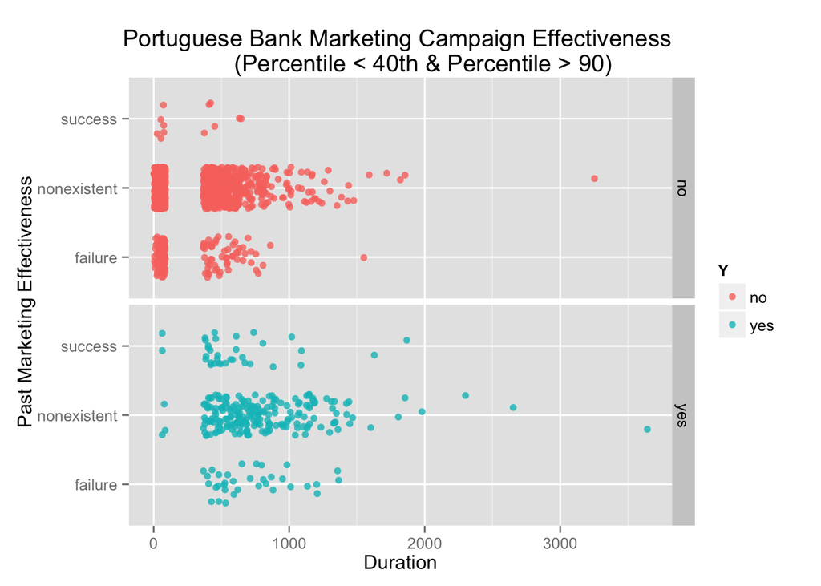

```
##
## > ggplot() + coord_cartesian() + scale_x_continuous() +
## +     scale_y_discrete() + facet_grid(Y ~ .) + labs(title = "Marketing Effectiveness (Percent ..." ... [TRUNCATED]
```

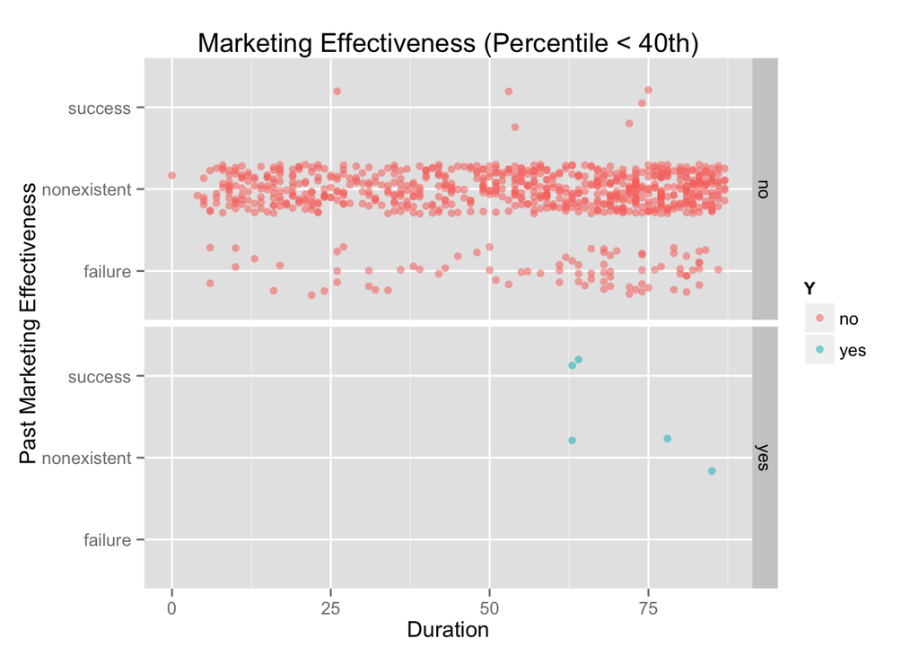

```
##
## > ggplot() + coord_cartesian() + scale_x_continuous() +
## +     scale_y_discrete() + facet_grid(Y ~ .) + labs(title = "Marketing Effectiveness (Percent ..." ... [TRUNCATED]
```

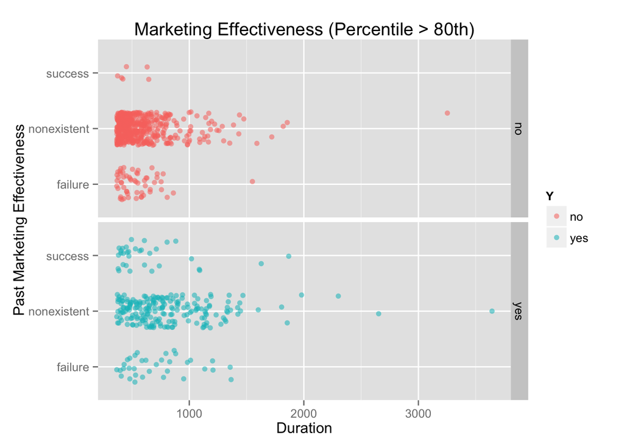

#### Method:

These visualizations are here to show the relationship between duration of marketing call and outcome of the marketing campaign on individuals. Also shown is the category of whether the past marketing campaign was effective.

## Demographics Visualization

```
##
## > require(tidyr)
##
## > require(dplyr)
##
## > require(extrafont)
##
## > require(ggplot2)
##
## > ahp <- df %>% select(AGE, HOUSING, LOAN, Y) %>% group_by(HOUSING,
## +     LOAN, Y) %>% summarise(medianAge = median(AGE), meanAge = mean(AGE),
## +     .... [TRUNCATED]
##
## > ahp
## Source: local data frame [10 x 7]
## Groups: HOUSING, LOAN [?]
##
##    HOUSING    LOAN      Y medianAge  meanAge     sdAge count
##     (fctr)  (fctr) (fctr)     (dbl)    (dbl)     (dbl) (int)
## 1       no      no     no      38.0 40.07468  9.957746  1406
## 2       no      no    yes      39.0 41.65169 13.426175   178
## 3       no     yes     no      37.0 39.78355  9.807091   231
## 4       no     yes    yes      39.0 41.79167 11.386411    24
## 5  unknown unknown     no      37.5 39.13542  8.677399    96
## 6  unknown unknown    yes      43.0 43.66667 12.864680     9
## 7      yes      no     no      38.0 39.87508  9.802433  1569
## 8      yes      no    yes      38.0 41.75510 13.203388   196
## 9      yes     yes     no      38.0 39.56284 10.136068   366
## 10     yes     yes    yes      42.5 43.13636 14.626499    44
##
## > result_labeller <- function(var, value) {
## +     value <- as.character(value)
## +     if (var == "Y") {
## +         value[value == "yes"] <- "Campaign Su ..." ... [TRUNCATED]
##
## > ggplot() + coord_cartesian() + scale_x_continuous() +
## +     scale_fill_discrete(name = "Campaign Result", breaks = c("yes",
## +         "no"), label .... [TRUNCATED]
```

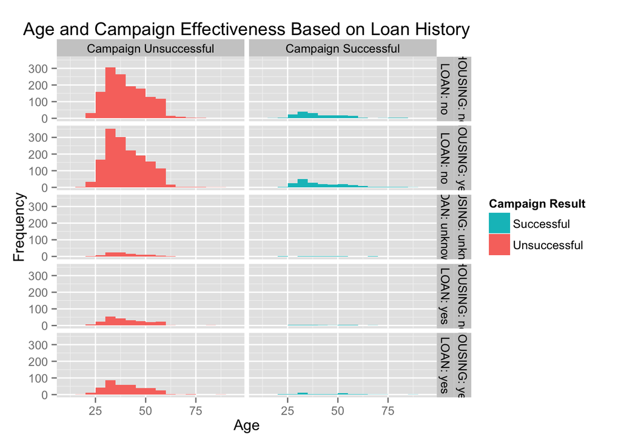

```
##
## > ggplot() + coord_cartesian() + scale_x_continuous() +
## +     scale_fill_discrete(name = "Campaign Result", breaks = c("yes",
## +         "no"), label .... [TRUNCATED]
```

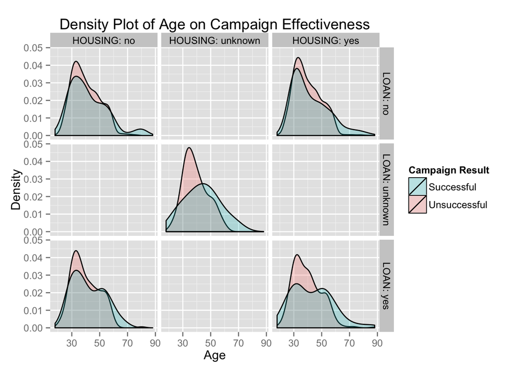

```r
#Shows the subset and summary of the data frame
source("../02 Data Wrangling/Demographics_AHP.R", echo = TRUE)
```

#### Method:

The question that we are trying to ask with these visualizations and R workflow is “What are the effects of age and other current loans on one’s williness to apply for a term deposit?”

The R workflow for these visualizations looks for statistical measures (mean age, median age, standard deviation of age, and total count) of the sampled population, grouped by their current loans and their decision to apply for a term deposit with the bank.

The two visualizations show how the target market of the bank’s marketing campaign ranged in age based on their current loans, and they compare the size and proportion of those who successfully subscribed for a term deposit after the campaign to those who did not subscribe. The first visualization is a histogram that utilizes facet_grid to graph the count of the campaign target population’s ages based on if they have a housing loan, if they have a personal loan and how they responded to the marketing campaign. The second visualization is a density plot that compares the relative density of age of those who subscribed to the term deposit to those who did not. This second visualization also uses facet_grid to further divide the two groups of respondents based on their current loan situation.

#### Findings:

Through the histogram visualization, we find that relative to those who have personal loans, those who do not have personal loans are more likely to subscribe to the term deposit regardless of if they have a housing loan. From the histogram, it is not clear whether this increase in campaign effectiveness is based on a real correlation between personal loan situations and willingness to subscribe to a term deposit, or if it is simply because much more of the data population do not have personal loans.

The density plot visualization helps to better look into the correlation between personal loans and willingness to subscribe to a term deposit. Through this visualization, we conclude that age plays a role in the campaign response of those who do and do not have personal loans. We find that those who currently do not have personal loans are more willing to subscribe to a term deposit if they are in their lower-30s (in age) than those who already have personal loans. This is best showcased through the differences in density plots of those who have housing loans and do not have personal loans to those who have both housing and personal loans (top right and bottom right graphs).

## Social Factors Visualization

```r
#Shows the subset and summary of the data frame
source("../02 Data Wrangling/SocialFactors_EC.R", echo = TRUE)
```

```
##
## > require(tidyr)
##
## > require(dplyr)
##
## > require(extrafont)
##
## > require(ggplot2)
##
## > SE_1 <- df %>% select(EDUCATION, AGE, Y) %>% filter(EDUCATION !=
## +     "unknown", EDUCATION != "illiterate") %>% arrange(Y)
##
## > ggplot() + coord_cartesian() + scale_x_discrete() +
## +     scale_y_continuous() + labs(title = "Portuguese Bank Marketing Campaign Effectiveness") + .... [TRUNCATED]
```

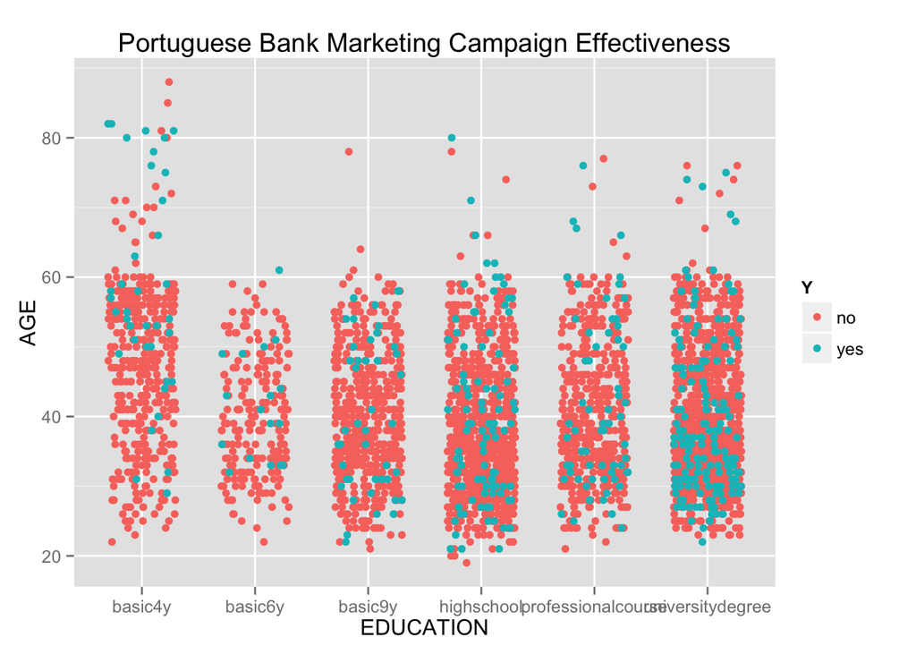

```
##
## > SE_2 <- df %>% select(MARITAL, AGE, Y) %>% filter(MARITAL !=
## +     "unknown") %>% arrange(Y)
##
## > ggplot() + coord_cartesian() + scale_x_discrete() +
## +     scale_y_continuous() + labs(title = "Portuguese Bank Marketing Campaign Effectiveness") + .... [TRUNCATED]
```

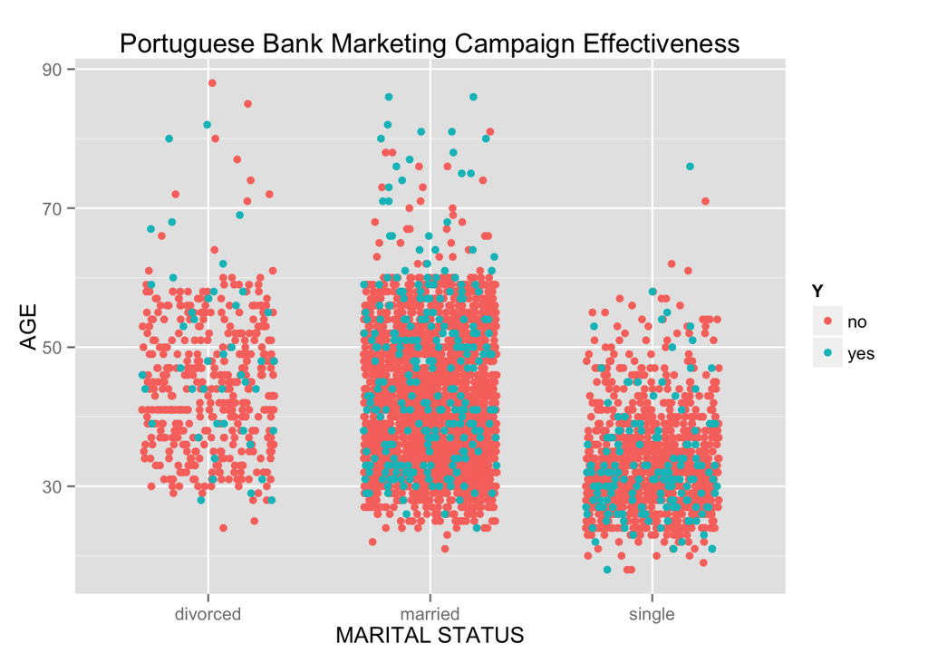

```
##
## > df %>% group_by(Y, MARITAL, EDUCATION) %>% filter(EDUCATION !=
## +     "unknown", MARITAL != "unknown", EDUCATION != "illiterate",
## +     AGE <= "65" .... [TRUNCATED]
```

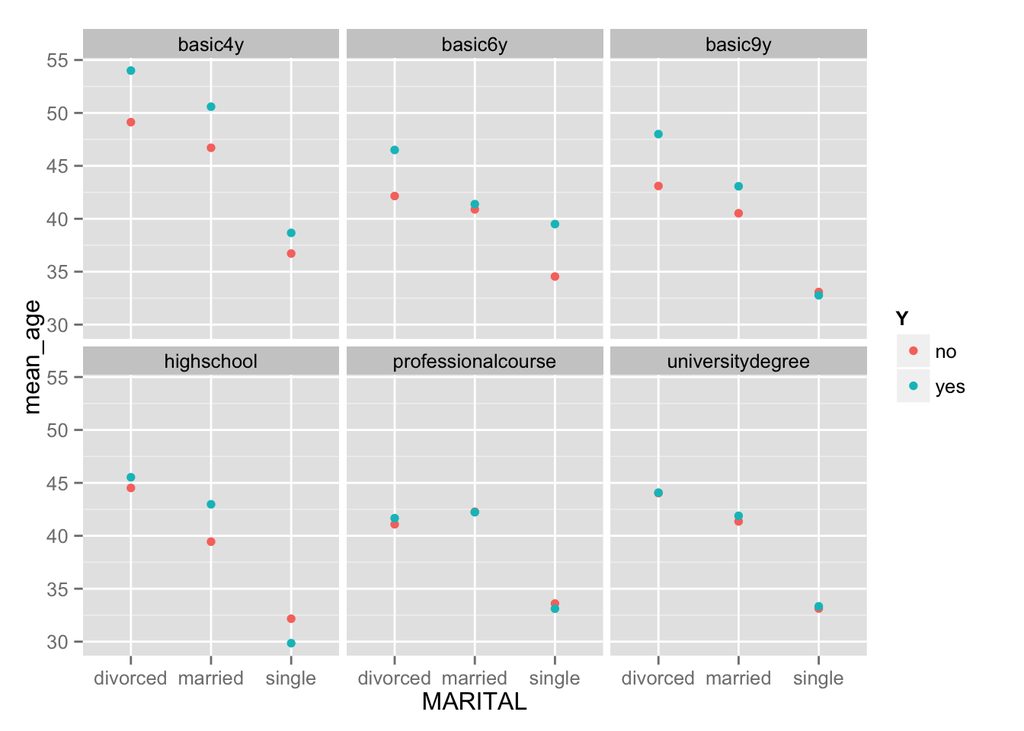

#### Method:

The first two graphs were intended to visualize the distribution of data across EDUCATION and MARITAL STATUS, compared to AGE. The first graph simply compared Education and Age, while filtering “unknown” and “illiterate” from EDUCATION. “Illiterate” was eliminated from all the graphs as there was only one data point from our data sample. The second graph likewise compared Marital Status and Age, while filtering out “unknown” from MARITAL STATUS. We chose to eliminate these “unknowns” from our visualization as they do not allow us to make any inferences from the data.

The third graph was our main visualization, supported by the first two graphs. In this visualization, we chose to utilize the group_by function for Marital Status, Education, and Y (yes/no decision to take a term deposit). As in the previous graphs, values with “illiterate”or “unknown” were eliminated as they did not allow for us to make any judgments on the data. Furthermore, we narrowed the age range to people between the ages of 10 and 65 as most of the data fell within that frame (as shown by the first two graphs), and we wanted to prevent outliers from having great influence. Next, we used the summarize function on age to extract the mean age of those who accepted/declined the term deposit. In order to examine the three factors of Marital Status, Education and Age, we implemented a facet on Education for cross examination.

#### Findings:

Our main findings were that, as education level becomes higher, age became a less influential factor in predicting whether individuals accepted/declined the term deposit, across marital status. Particularly in the “basic4y” block, it’s evident that the difference in mean_age is the greatest compared to other education levels. As education level increases, this gap decreases - even across marital status. Moreover, as education level increases, individuals agreed to the term deposit at an earlier age.

As a result of this data analysis, we predict that individuals agreed to the term deposit as their higher education level most likely meant that they had higher paying jobs. Consequently, individuals would have the security of significant financial resources to place a considerable amount of money at a younger age without worrying about being unable to access their funds for a considerable number of years in the future. The examination of marital status displays a similar story. The mean age of the divorced and married individuals do not drastically change across education levels (with the exception of the “basic4y” block). However, there is a significant drop in mean age for the singles group (especially in the “highschool” block). One can safely conclude that education is a great source of security for singles, as they do not need to be concerned about providing for their spouse or family, therefore they may be more willing to take financial risks and accepted the term deposit.

For possible future analysis, it would be interesting to examine the marketing effectiveness based on family, such as number of children/dependents, or examine what category those who indicated “unknown” for marital status fall into (e.g. single parent).